# Modelling the demographic distribution of the global refugee population

Jan Beise, Yukun Pei (UNICEF), Sebastian Steinmueller (UNHCR)

Version: 2021-11-03

# Descriptive analysis

- Describe UNHCR official population statistics content and compilation
- Show and explore structure of data sets: especially asylum - origin - location
- Show origin and asylum country structure in missing and non-missing demographic data
- Explore differences in demographic structure for origin and asylum countries with high proportion of available data

## Data set

UNHCR compiles official statistics on stocks and flows of forcibly displaced and stateless persons twice a year, once for mid-year figures (Mid-Year Statistical Reporting, MYSR) and once for end-year figures (Annual Statistical Reporting, ASR). For these reporting exercises, country operations compile aggregate population figures from a range of sources and data producers such as governments, UNHCR’s own refugee registration database proGres and sometimes non-governmental actors. The figures undergo a statistical quality control process at the country, regional and global level of the organisation and are disseminated on the publicly available refugee data finder (https://www.unhcr.org/refugee-statistics/) after applying statistical disclosure control to suppress very small counts of persons that could identify individuals.

The end-year figures compiled with reporting date 31 December contain sex- and age breakdowns of the stocks of displaced and stateless people under UNHCR’s mandate. Table 1. displays the sex- and age-disaggregated data on the stock of refugees under UNHCR’s mandate (including Venezuelans displaced abroad, excluding Palestine refugees under UNRWA’s mandate). The data is available by country of origin, country of asylum and within country of asylum on sub-national level as indicated by the variables *location* and *urbanRural*. Variable *statelessStatus* displays whether the reported population is stateless (“STL” and “UDN”) or not stateless (“NSL”). The variables [sex]_[agebracket] contain the counts of refugees as of 31 December 2020 in the individual sex and age brackets in the respective geographic/stateless combination. For example, *female_12_17* contains the number of female refugees aged 12 to 17. Variable *totalEndYear* is the total number of refugees over all sex/age categories.

Pre-defined sex-specific age brackets are 0-4, 5-11, 12-17, 18-24, 25-49, 50-59 and 60 years and older. For some population groups, data is only available for the overall 18-59 age group instead of for the finer brackets in this age range. For others, only sex-disaggregated data without age information is available, and finally there are population groups for which only the total end-year count without any demographic information is available. These different levels of disaggregated data availability is recorded in variable *typeOfDisaggregation* in the dataset: “Sex/Age fine” for the most granular age brackets, “Sex/Age broad” for populations reported with the 18-59 age bracket, “Sex” where only counts of female and male refugees are available without age information and “None” for populations without any available demographic information.

Table 1: Demographic breakdown of UNHCR refugee population end 2020

| asylum_country | origin_country | location | urbanRural | statelessStatus | female_0_4 | female_5_11 | female_12_17 | female_18_24 | female_25_49 | female_50_59 | female_18_59 | female_60 | femaleAgeUnknown | female_children | female_adults | female | male_0_4 | male_5_11 | male_12_17 | male_18_24 | male_25_49 | male_50_59 | male_18_59 | male_60 | maleAgeUnknown | male_children | male_adults | male | children | … |
| --- | --- | --- | --- | --- | --- | --- | --- | --- | --- | --- | --- | --- | --- | --- | --- | --- | --- | --- | --- | --- | --- | --- | --- | --- | --- | --- | --- | --- | --- | --- |
| Afghanistan | Iran (Islamic Republic of) | Herat : Wilayat - Province | U | NSL | 2 | 1 | 0 | 0 | 2 | 1 | 3 | 3 | 0 | 3 | 6 | 9 | 1 | 0 | 0 | 3 | 9 | 1 | 13 | 3 | 0 | 1 | 16 | 17 | 4 | … |
| Afghanistan | Iran (Islamic Republic of) | Kabul : Wilayat - Province | U | NSL | 0 | 0 | 0 | 0 | 3 | 0 | 3 | 0 | 0 | 0 | 3 | 3 | 0 | 0 | 0 | 2 | 6 | 0 | 8 | 0 | 0 | 0 | 8 | 8 | 0 | … |
| Afghanistan | Iraq | Kabul : Wilayat - Province | U | NSL | 0 | 0 | 0 | 0 | 0 | 0 | 0 | 0 | 0 | 0 | 0 | 0 | 0 | 0 | 0 | 0 | 0 | 1 | 1 | 0 | 0 | 0 | 1 | 1 | 0 | … |
| Afghanistan | Pakistan | Kabul : Wilayat - Province | U | NSL | 2 | 4 | 8 | 12 | 23 | 3 | 38 | 1 | 0 | 14 | 39 | 53 | 7 | 16 | 8 | 8 | 15 | 5 | 28 | 0 | 0 | 31 | 28 | 59 | 45 | … |
| Afghanistan | Pakistan | Kandahar : Wilayat - Province | U | NSL | 0 | 2 | 1 | 2 | 1 | 0 | 3 | 0 | 0 | 3 | 3 | 6 | 0 | 0 | 0 | 1 | 0 | 1 | 2 | 0 | 0 | 0 | 2 | 2 | 3 | … |
| Afghanistan | Pakistan | Khost : Wilayat - Province | R | NSL | 1756 | 2633 | 1170 | 1280 | 1975 | 219 | 3474 | 146 | 0 | 5559 | 3620 | 9179 | 1463 | 2999 | 914 | 841 | 1575 | 329 | 2745 | 37 | 0 | 5376 | 2782 | 8158 | 10935 | … |

## Distribution of missing and observed demographic data

Table 2: Demographic data availability for UNHCR refugee population end 2020

| typeOfDisaggregation | totalEndYear | Percentage of population | nAsylum | Percentage of countries of asylum |
| --- | --- | --- | --- | --- |
| None | 5288880 | 21.578756 | 75 | 34.883721 |
| Sex | 863474 | 3.522994 | 17 | 7.906977 |
| Sex/Age broad | 3030784 | 12.365671 | 17 | 7.906977 |
| Sex/Age fine | 15326523 | 62.532578 | 106 | 49.302326 |

Table 2 shows the availability of sex/age-disaggregated data by the global number of refugees and countries of asylum. Age- and sex-disaggregated data is available for 75 per cent of the global refugee population and data disaggregated only by sex for a further 4 per cent.

UNHCR has in the past reported the sex/age breakdown in the available data as global and regional aggregates of the demographic distribution of all refugees. Figure 1 shows the proportion of female and male children and adults in the global refugee population with available demographic data, with 46 per cent children under the age of 18 and 49 per cent women and girls among the population.

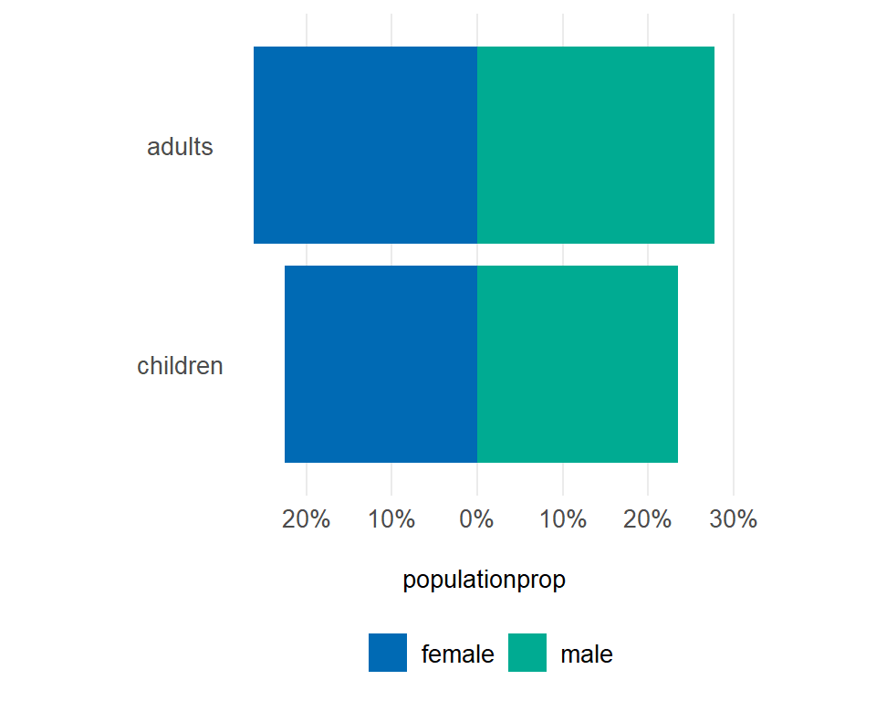

Figure 1: Sex/age distribution of refugees with available data end 2020

In figure 2), we see the split between female and male refugees in each age bracket with available data, with a slight surplus of boys and men in all age groups up to 59 years and slightly more women than men among refugees aged 60 and older.

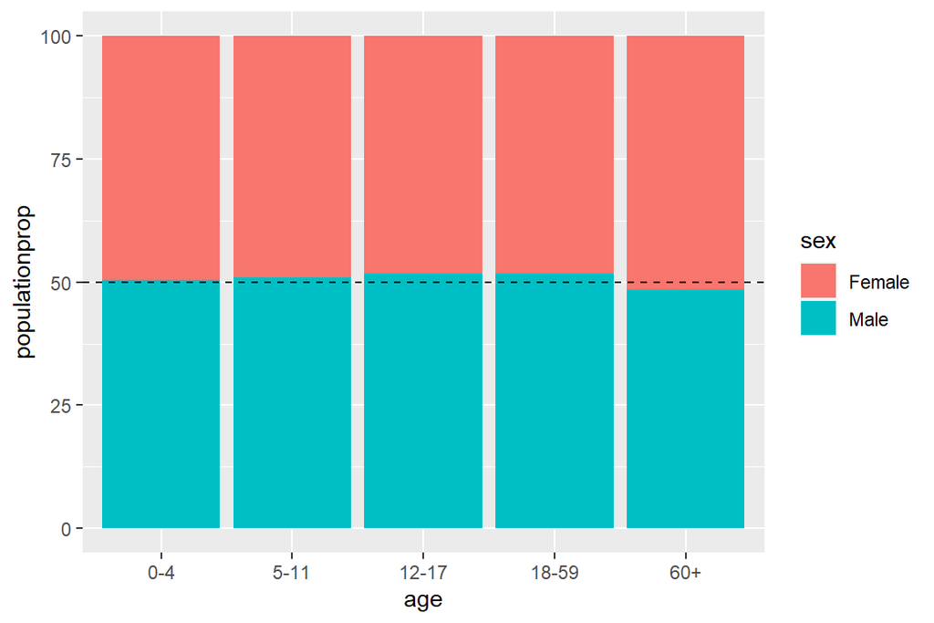

Figure 2: Sex distribution within age brackets of refugees with available data end 2020

By reporting the observed demographic distribution as the sex/age structure of the entire refugee population including the part without available data, we are assuming that the 25 per cent for whom no age information was available at the end of 2020 have the same age distribution as the ones with available data. It is difficult to check this very strong assumption of ignorability of the missing data without further information on the sex/age distribution in the missing part of the data. We can however compare the distribution of other, fully available variables between refugees with and without demographic information. If such variables can be assumed to be correlated with the sex/age distribution at least to some extent, this can give us an indication whether the ignorability assumption is likely to be justified or not.

In particular, we can look at the distribution of data availability by country and region of asylum, and we can furthermore compare the distribution of origins of refugees in the observed and the unobserved part of the population. If missingness of demographic data was entirely random and thus ignorable, we would expect the geographic origins of refugees to be similar in the observed and the unobserved part of the demographic data, that is, we would see a similar distribution of origin countries.

Statelessness and the urban/rural variable are other variables for which we could in principle check distributions among refugees with and without observed demographic data. Variable *urbanRural* however is not measured reliably in all reporting countries of asylum, and *statelessStatus* can be assumed to suffer from underreporting that might be correlated with missingness in demographic data, making it a less than ideal measure of ignorability. We will therefore focus on the distribution of countries and regions of asylum and origin, both of which are measured reliably and with little missing data. Country of asylum is available for the entire population due to the way UNHCR’s official population statistics are reported by country offices, and country of origin is available except for a very low proportion of refugees.

Some questions we are particularly interested in answering through the following descriptive analysis:

1. Can we assume that the sex/age distribution in the population with missing data is the same as in the population with available data?
2. Is the demographic composition of refugee populations from the same country of origin similar in different countries of asylum?
3. Is the demographic composition of refugee populations in the same country of asylum similar over different countries of origin?
4. Are refugee populations from the same country of origin similar to each other in neighbouring countries of asylum and in countries in the same region?
5. Does the demographic distribution of a population from the same origin vary significantly across locations within the same country of asylum?

Adressing these questions will help us decide whether the approach to date of assuming ignorability of missing demographic data is justified and if not, which modelling approaches can help us estimate the demographic distribution and variability of the missing data part.

### By region of origin

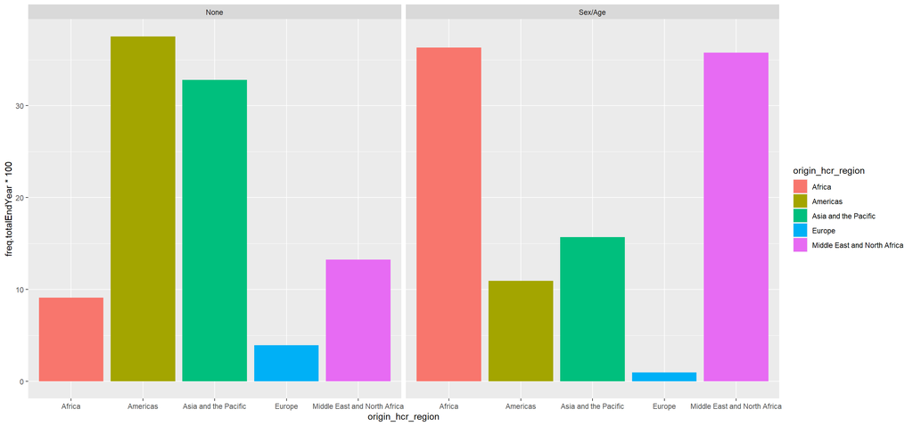

Figure 3: Proportion of refugees in each origin region by demographic data availability, end 2020

Figure 3) shows the distribution of refugees by origin regions separately for the two subsets of the global refugee population without (left side) and with (right side) sex/age-disaggregated data (population with sex- but not age-disaggregated data omitted for clarity). The most common origin regions are Sub-Saharan Africa and the MENA region for refugees with available demographic information.Those without demographic data availability have most commonly fled from countries in the Americas and the Asia-Pacific region. This provides a first indication that refugees with available sex/age-disaggregated data are fundamentally different from those without such data, and that we cannot simply assume the same demographic distribution between these two groups.

### By region of asylum

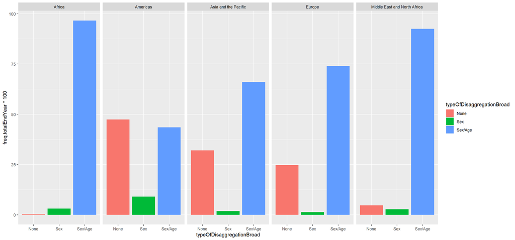

Figure 4: Demographic disaggregation coverage by region of asylum

Figure 4) shows for what proportion of the refugee population living in each region sex- and sex/age-disaggregated data was available at the end of 2020. While demographic coverage is close to universal for refugees hosted in the Sub-Saharan Africa and the MENA regions, it is available for 74 per cent of refugees in Europe, 66 per cent in Asia and the Pacific and only for 44 per cent in the Americas. This is to a large extent a result of the differing population data sources in these regions: While the individual demographic details of refugees in many countries in Africa and MENA are recorded in UNHCR’s own case registration system proGres, population data in other regions often comes from government offices with varying degrees of availability of demographic data.

## Data coverage histogram

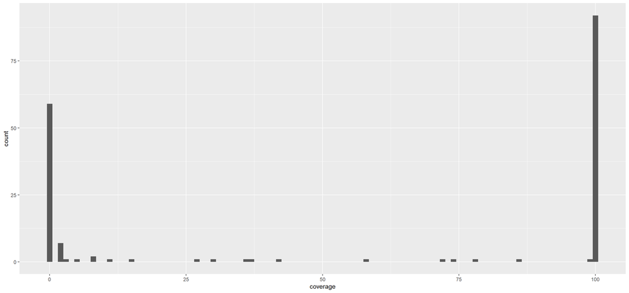

Figure 5: Data coverage by country of asylum

Figure 5) shows the distribution of the number of countries of asylum according to the demographic coverage. It clearly demonstrates that for almost all countries, the demographic coverage is either 0 per cent (left bar), or 100 per cent (right bar). This is to be expected since for most countries of asylum, demographic data will be produced by the same source, e.g. by a government office or by UNHCR, with the same demographic coverage for all refugee populations regardless of country of origin.

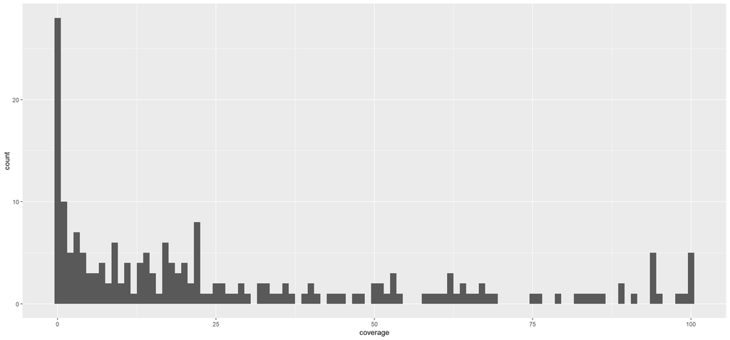

Figure 6: Data coverage by country of origin

Figure 6) in turn shows the distribution of the number of countries origin according to the demographic coverage. The large bar on the left for example stands for the number of countries of origin for which there is no demographic data on their refugees at all. While this is the case for populations from a lot of origin countries, there are also many origin populations for which there are varying degrees of data availability. This can be explained by their dispersion over different countries of asylum with differing data availability in each of them.

## Demographic distribution from selected countries of origin

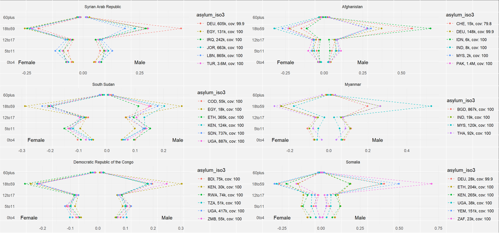

Figure 7: Age and sex composition from same origin country and different asylum countries (Top 6 origin countries)

## Demographic distribution in selected countries of asylum

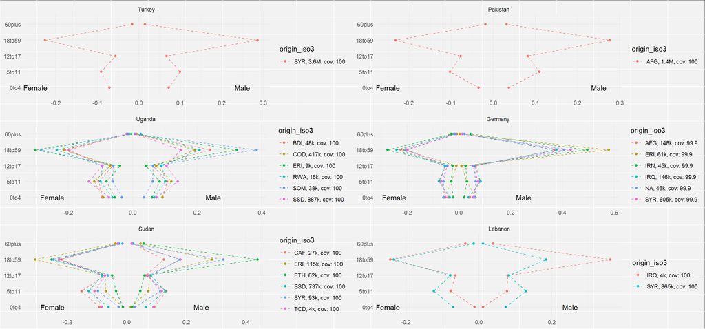

Figure 8: Age and sex composition from same asylum country and different origin countries (Top 6 asylum countries)

## Compare refugee population’s age distribution with origin and asylum country’s age distribution

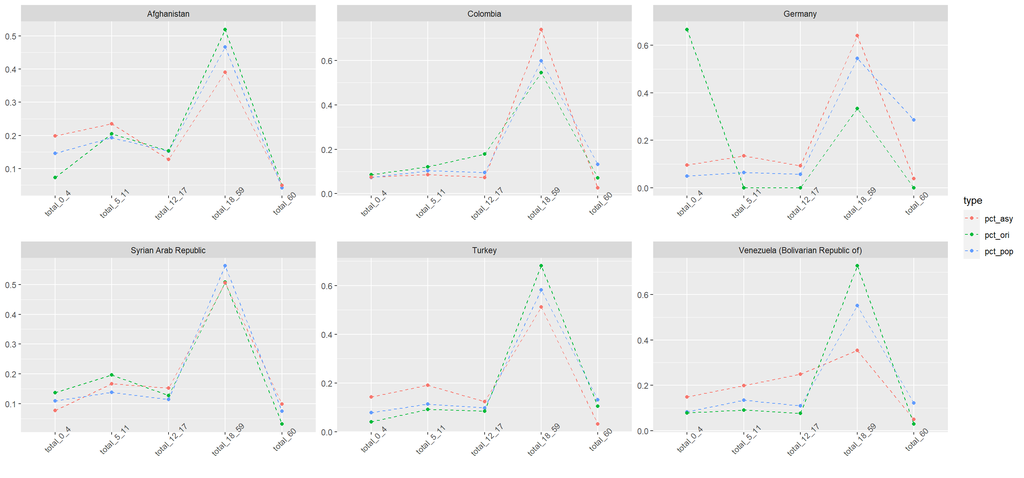

Figure 9: Compare demographic distribution from selected countries

## Marginal analysis on Distance, Neighboring country, Economic status

In the meeting we discussed that distance between origin and destination countries, whether origin and destination are neighboring country, and the economic status between origin and destination countries may be the factor that could explain the variance. Below I will analyse how these three factors may influence the demographic composition of refugees.

### Distance

Distances are calculated between centroids of countries, measured by meter.

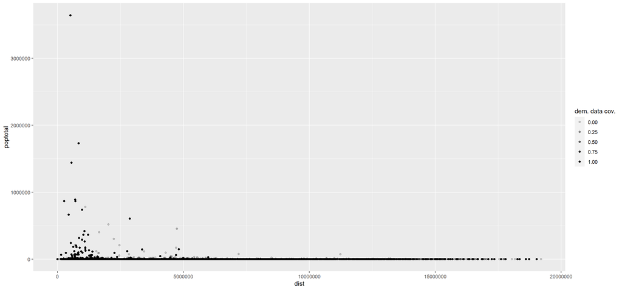

Figure 10: Total population and data coverage by distance

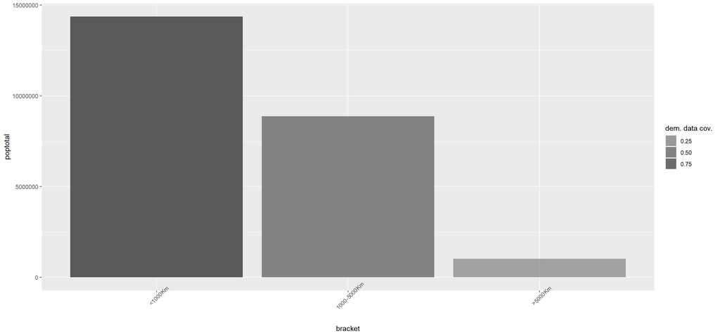

Figure 11: Total population and data coverage by distance, in brackets

From 10 and 11 we can see, the total population of refugee decreases when the distance between origin and asylum countries become further. The demographic data coverage of distant refugee movements are also getting lower.

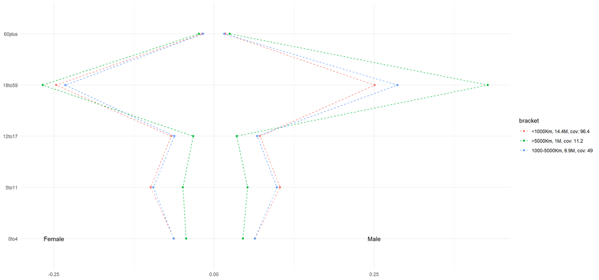

Figure 12: Age and sex composition grouped by travel distance, world

12 shows that the demographic composition of refugees moving within 1000 Km and moving 1000 Km - 5000 Km are close. We can see a big difference in demographic composition for refugees moving more than 5000 Km, where those refugees are older and their gender is more male-dominant. But the low data coverage for this distance bracket casts a shadow on the inference.

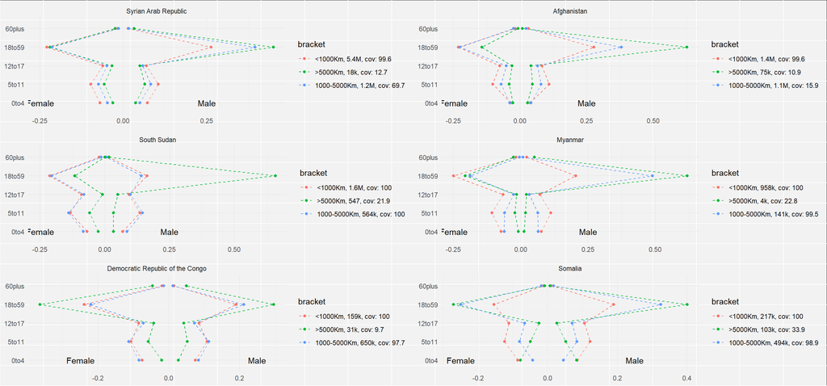

Figure 13: Age and sex composition grouped by travel distance, Top 6 origin countries

When zooming into country-level data, 13 shows that except for South Sudan and Dem. Rep. Congo, most countries have a trend that the refugees tends to be older and male-biased when traveling further, by comparing <1000Km group and 1000-5000Km group. All 6 countries have low demographic data coverage for >5000Km group.  
To conclude, generally speaking, the distance between origin and destination countries may be a factor that impacts demographic composition of refugees, but for some countries (mostly Sub-Saharan African countries) this might not be true. Also, the data coverage for refugees with longer travel distance are low.

### Neighboring Country

The countries that sharing a piece of border is defined as neighboring country.

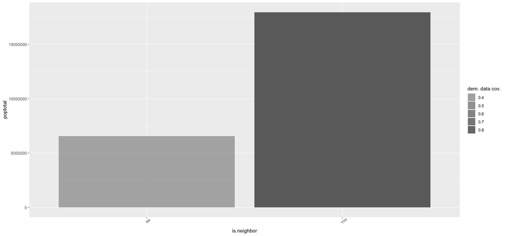

Figure 14: Total population and data coverage by if the origin and destination countries are neighbors

From 14 we can see, same as the distance criteria, the neighboring country criteria still has the low data coverage issue. 27 per cent of refugees are traveling to countries of asylum not neighboring their home country while the demographic data for this population is only about 36%.

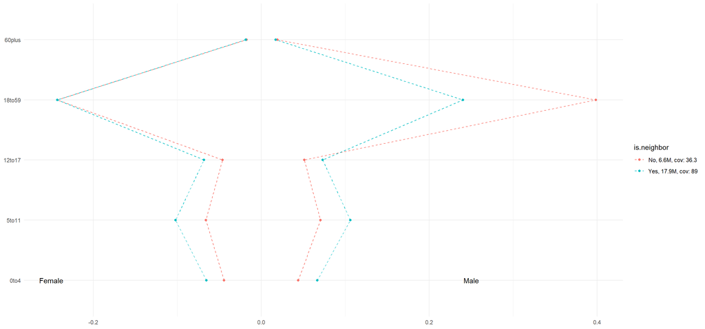

Figure 15: Age and sex composition grouped by neighboring status, world

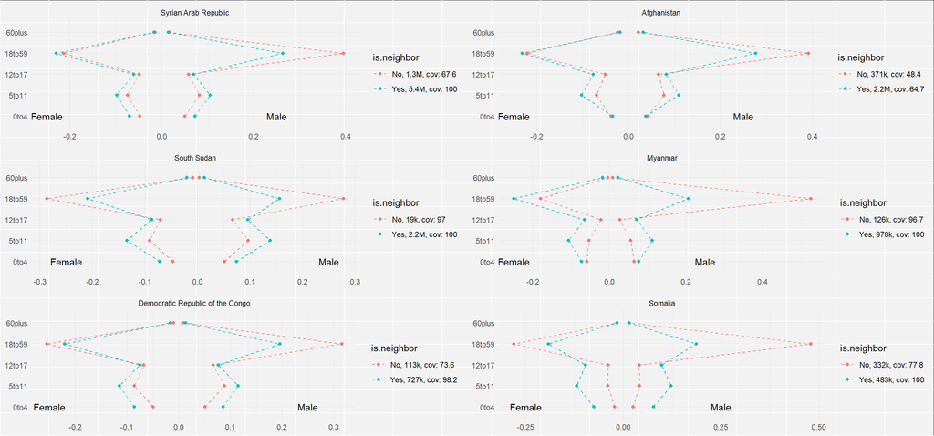

Figure 16: Age and sex composition grouped by neighboring status, top 6 origin countries

Above plot shows that for the top 6 origin countries of refugees, with high data coverage, When going to non-neighboring countries, the proportion of adult male will increase significantly. This may due to the high cost of time and effort required to travel to non-neighboring countries.

### Economic status

Here every origin and destination country is assigned with World Bank income class classification, with 4 levels: Low income, Lower middle income, Upper middle income, and High income. So if a refugee traveling from a lower income level country to a higher income level country, then he is marked by ‘(he/she is traveling to a) Higher income lvl’ in column ‘status.change’ and vice versa.

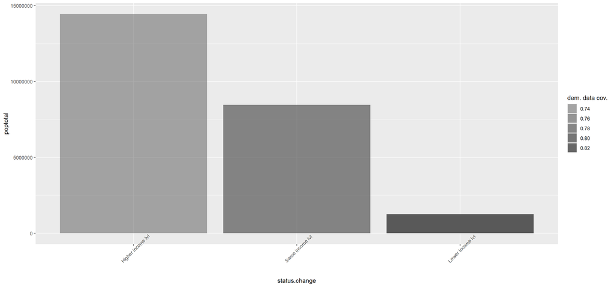

Figure 17: Total population and data coverage by the origin and destination countries’ income level

From above plot we can see that majority of refugees are traveling to an asylum country that has a same or higher income level than his/her original country. Surprisingly, the demographic data coverage is high among all three situations, making it a potential good predictor.

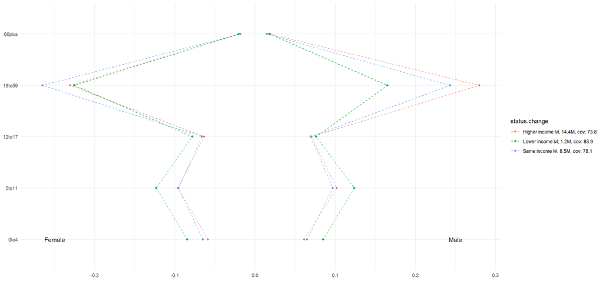

Figure 18: Age and sex composition grouped by the origin and destination countries’ income level, world

On world level, the refugees traveling to higher income level countries tends to be older and more male-dominant.

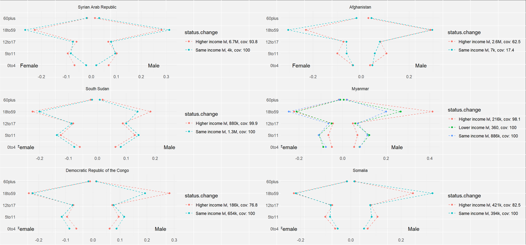

Looking at top 6 origin countries of refugee, the situation varies. For South Sudan, Myanmar, and Dem. Rep. Congo, it’s similar to the global situation. For country like SAR and Afghanistan, the demographic composition of refugees that traveling to higher income level countries are quite the same. Somalia is an outlier where there are more males when traveling to countries with same income level as Somalia rather than higher.

## Chord diagram for origin-asylum subregion pair of refugee stocks in 2020, transparency according to demographic data coverage

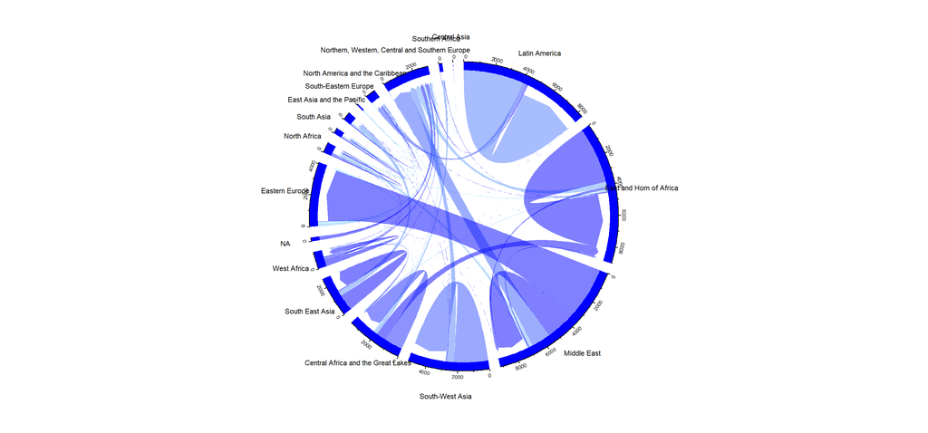

Figure 20: Chord diagram